# Exploring 2016 U.S. Primary Election’s Financial Contribution and Expenditure

### Comparing States Generosity

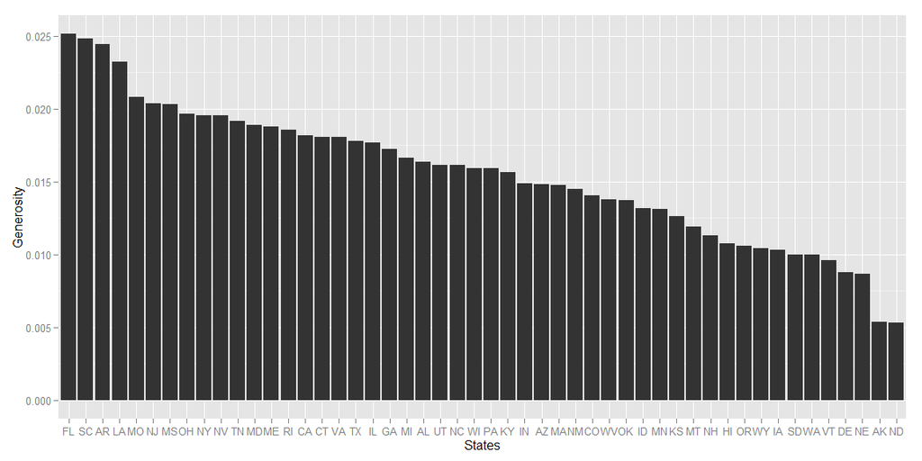

Florida, South Carolina, and Arkansas have taken the top spots on this graph. These States, while have average involvement, top the “generosity chart” because their contributors write relatively big checks comparing with the States’ GDP per capita.

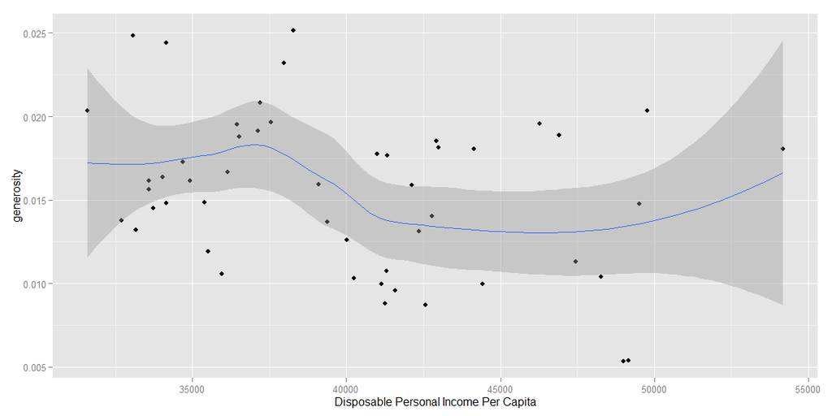

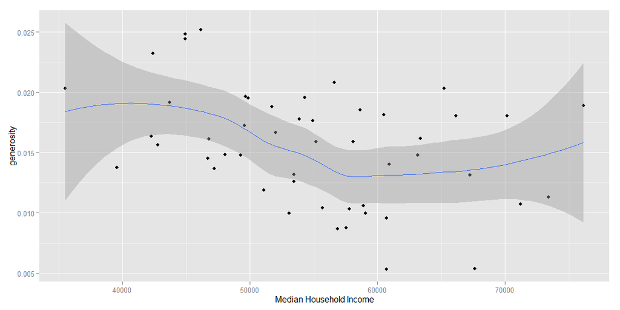

There are no correlations between generosity and the economics features either. Now just for fun, let’s see how Median Household Income measures, GDP per capita, and DPI per capita correlate

### Median Household Income vs GDP per capita vs DPI per capita

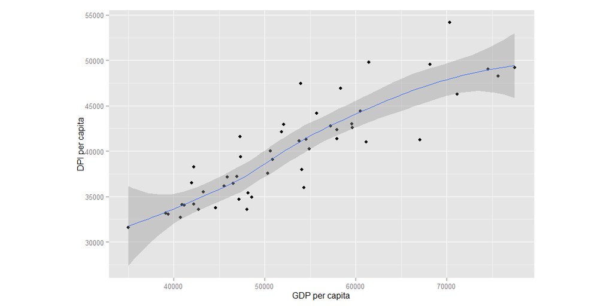

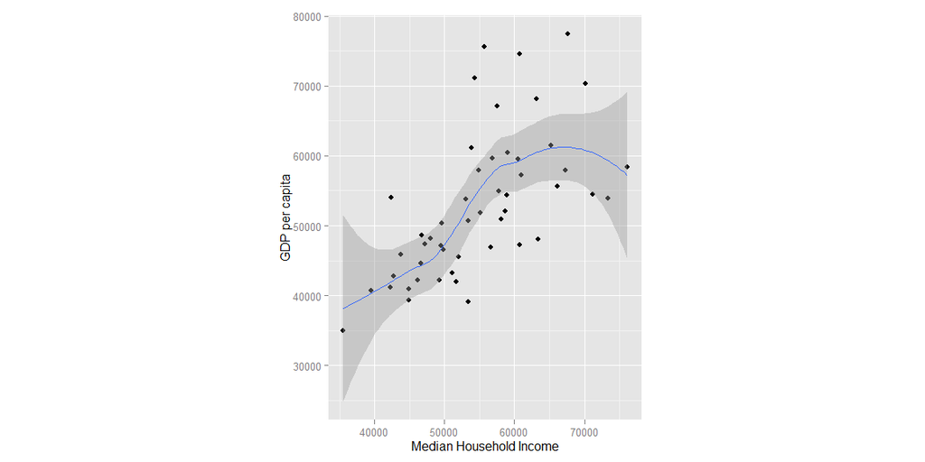

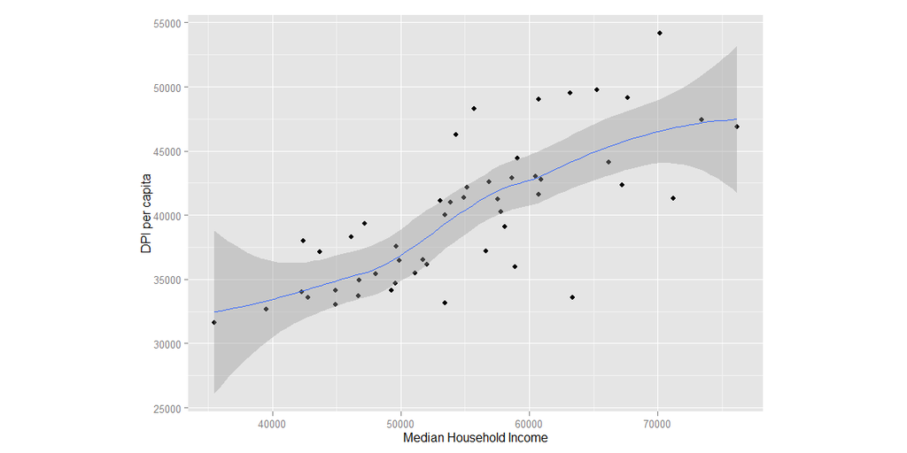

## E. Bivariate Analysis

### Talk about some of the relationships you observed in this part of the investigation. How did the feature(s) of interest vary with other features in the dataset?

The Total Contribution is proportional with the States’ economics features like GDP and DPI. The Number of Contributiors is also strongly correlated with Population.

Surprisingly, the number of contributors has no correlations with GDP per capita, DPI per capita, and Median Household Income like I suspected. In fact, no features in this dataset could explain the number of contributors per state.

### What was the strongest relationship you found?

The strongest relationship is Contribution vs Contributors with coefficient of 0.99.

## F. Multivariate Plots

### Comparing Candidates’ Contribution Received from Individuals

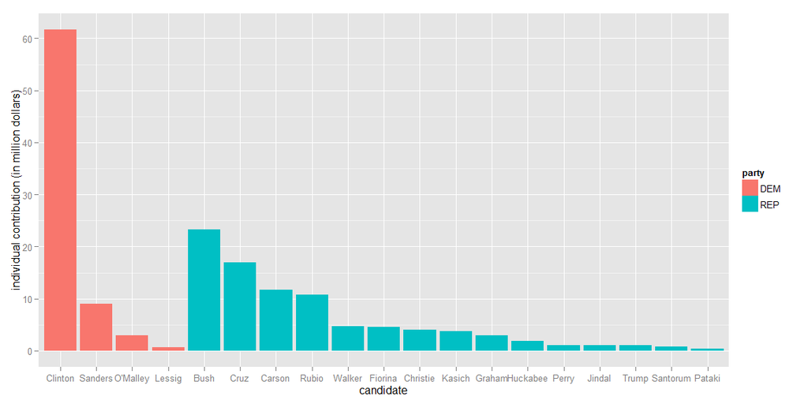

Another interesting takeaway from this graph is that, Donald Trump, a front-runner on the Republican side, only received a mere 1 million dollars in individual contribution, according to this FEC data. Eventhough this is believable since Trump announced awhile back that he won’t accept donation money, there were [reports in October](http://thehill.com/homenews/campaign/257106-trump-saves-his-own-money-thanks-to-38-million-in-donations) asserting that Trump have received nearly 4 millions dollars in donations. Let’s have a look at net contribution from all sources

### Comparing Candidates’ Net Contribution

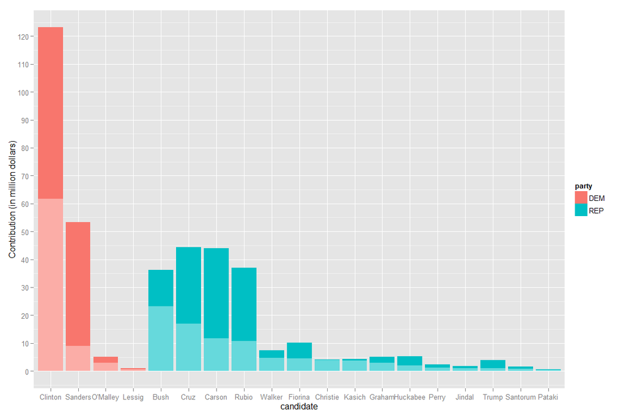

In this graph, the lighter colored segment of each bar indicates the individual contribution portion of the total contribution. Clinton’s still in the lead with a big gap between her and other candidates. Sanders, whoes number has increased 5 times, comes out ahead of all Republican candidates. Cruz, Carson, and Rudio have overtaken Bush as well. Also, Trum’s number is now close to 4 million like reported.

### Comparing Candidates’ Number of Contributors

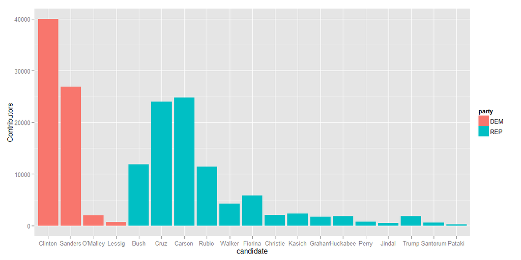

### Comparing Candidates’ Average Individual Contribution

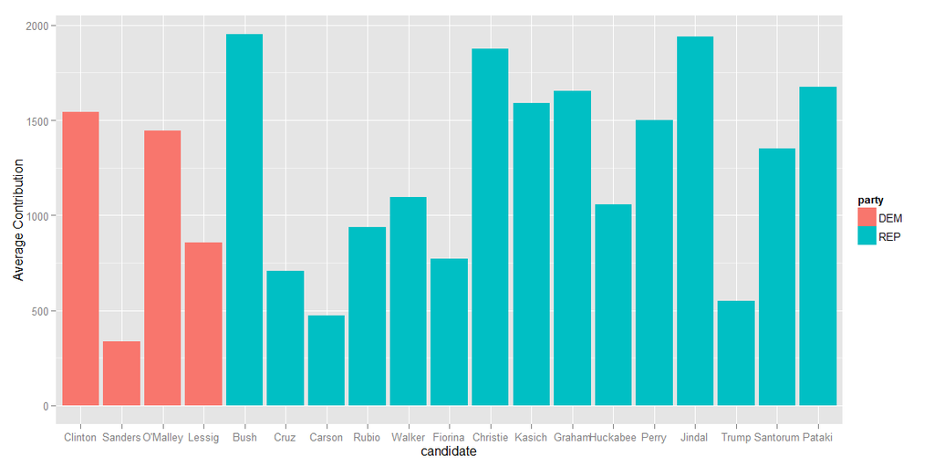

My prediction was correct, Sanders does have the lowest contribution mean. I’m rather surprised at Christie’s and Jindal’s high contribution means. These candidates didn’t have a lot of contributors nor the total amount of countribution, but they sure do get big checks from the few contributors they have.

### Comparing Candidates’ Net Operating Expenditure

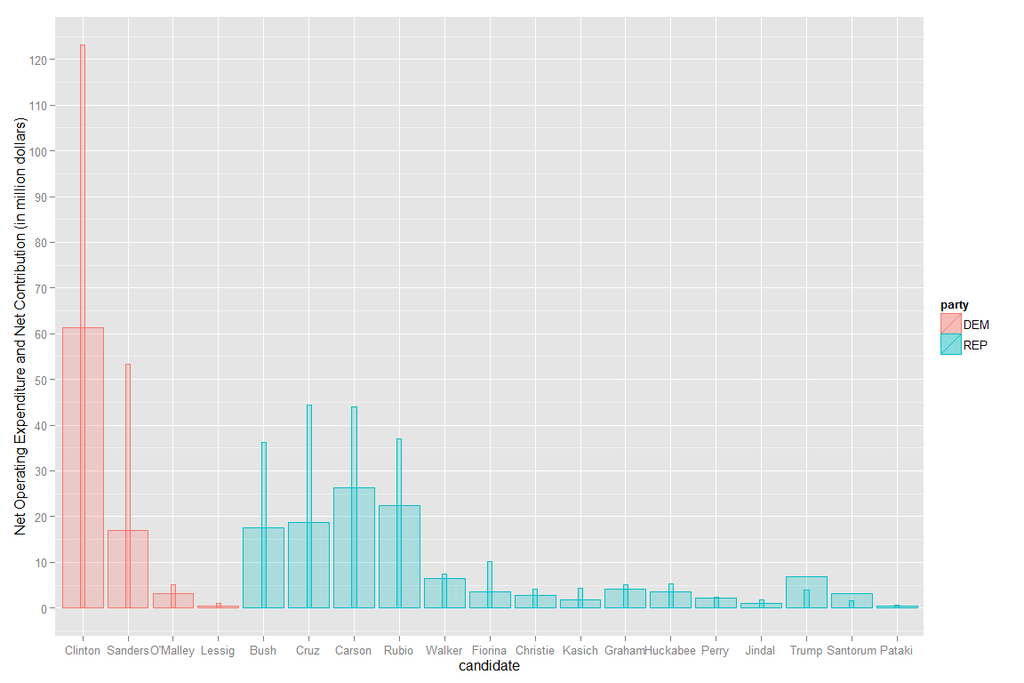

(In this graph, the thick bars show us the expenditure amount and the thin bars show the total contribution received for reference.)

For most candidates, the amount spent is proportional with the amount received. Santorum and Trump are the only two candiates with total spending greater than net contribution, indicating that these candidates might have paid for things out of pocket.

### Comparing Number of Contributors by Occupations

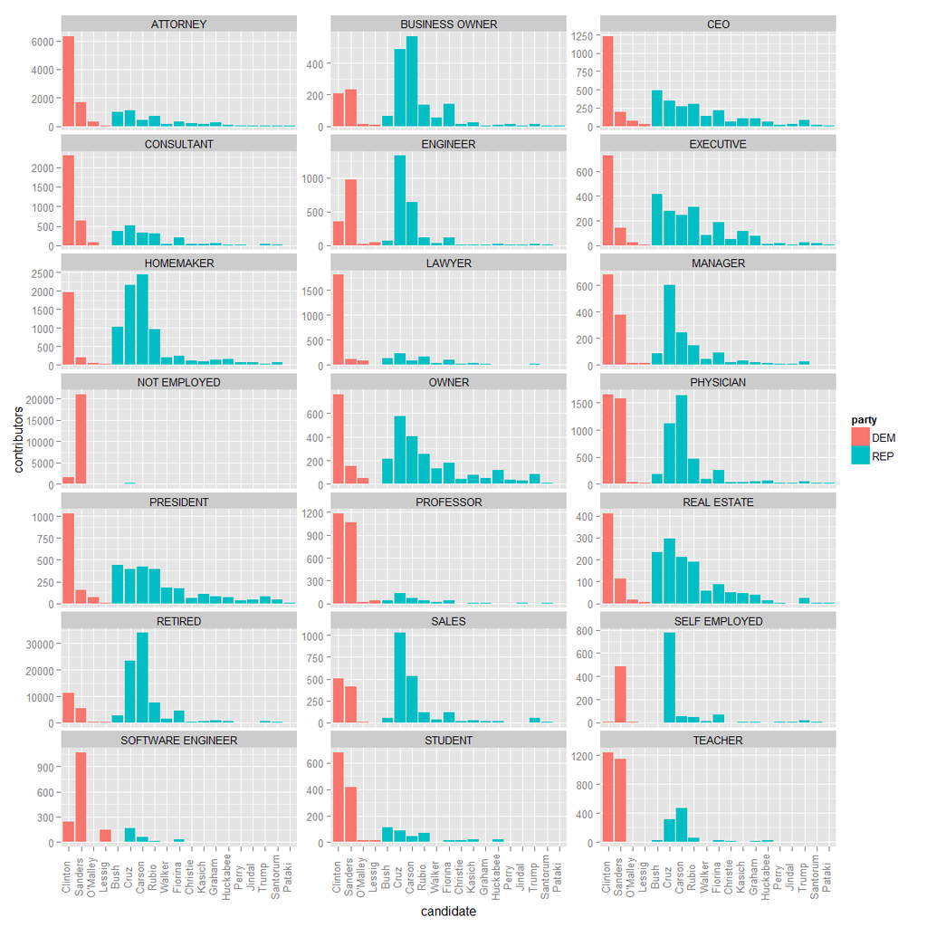

Interestingly enough, Software Engineers also much prefer Sanders than other candidates. In Education (Students, Teachers, Professors), Clinton and Sanders, the Democrat’s front runners, are also very popular. Meanwhile, the retired are mostly on the Republican’s side.

### Comparing Spending by Regions

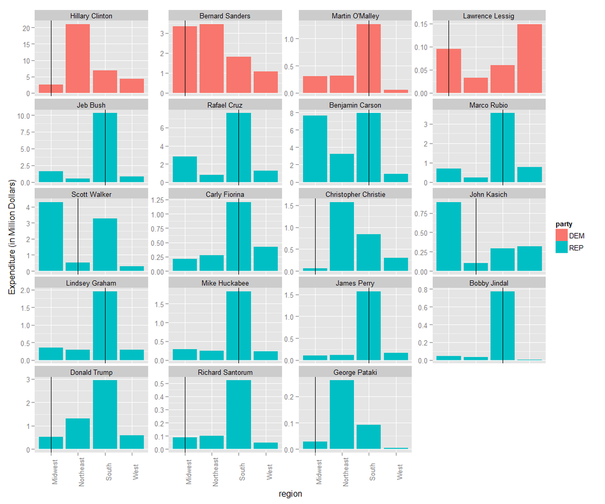

(In this graph, the veritical black line mark the candidate’s home region) Interestingly enough, the Republican candidates spent a lot of money in the Southern States, whether it’s their home region or not.

### Comparing Contribution Cummulated Over Time of Top candidates

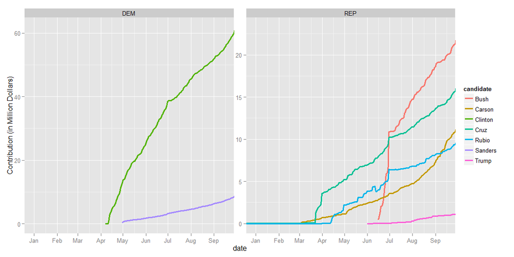

(Top 2 Demoractic Candidates are Clinton and Sanders. Top 5 Republican candidates are Trump, Carson, Rudbio, Cruz and Bush. As of Nov 22nd, 2015 from [realclearpolitics.com](http://www.realclearpolitics.com/epolls/2016/president/us/2016_democratic_presidential_nomination-3824.html))

### Comparing Expenditure Cummulated Over Time of Top candidates

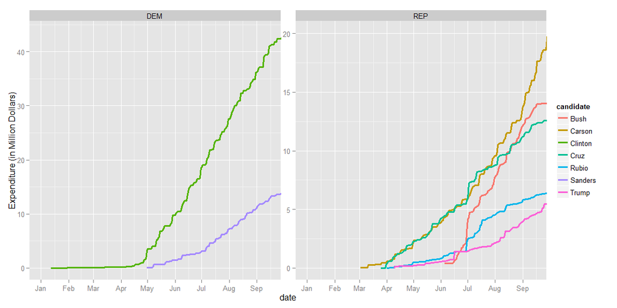

Even with the steep raise in contribution as seen in the previous graph, Bush’s spending has always been lower than Carson’s.

### States: Population vs. Contribution vs. Expenditure

Now just for fun, Let’s see if we can compare 3 different numerical variables in one chart:

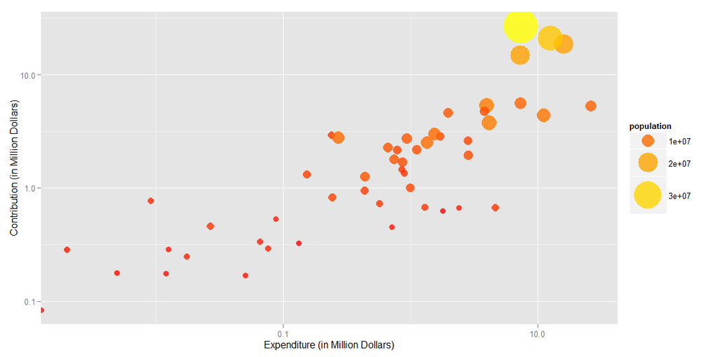

This graph by itself shows that Contribution is proportional with Expenditure, Expenditure is proportional with Population, and Population is proportional with Contribution.

## G. Multivariate Analysis

(Note: I find it very awkward answering the questions below. My datasets, as it turned out, do not quite fit the provided project template. Many of my features of interest are cetegorical (States, Candidates, Regions, Occupation…), not numerical. So, asking to how strong a relation between these features does not make much sense.)

### Talk about some of the relationships you observed in this part of the investigation. Were there features that strengthened each other in terms of looking at your feature(s) of interest?

We found out that the average contribution toward Bernie Sanders was the smallest of all cadidates. That means his contributors often write smaller checks. We later examined the contributors’ occupations, and discovered that Sanders is super popular among the unemployed, students and teachers. This finding is in-line with the small average contribution finding.

### Were there any interesting or surprising interactions between features?

Trump, the front runner on the Republican side, received very little in contribution. This is of no surprise since Trump himself claimed that he could fund his own campaign because he could afford it. However, his spending, eventhough reported to be higher the net contribution received, in nowhere near as high as all other popular candidates. Yet, he’s leading the Republican. Either Trump is super effective in campaigning or the FEC does not require report on spending from money out of pocket.

# 2. Final Plots

## Plot One

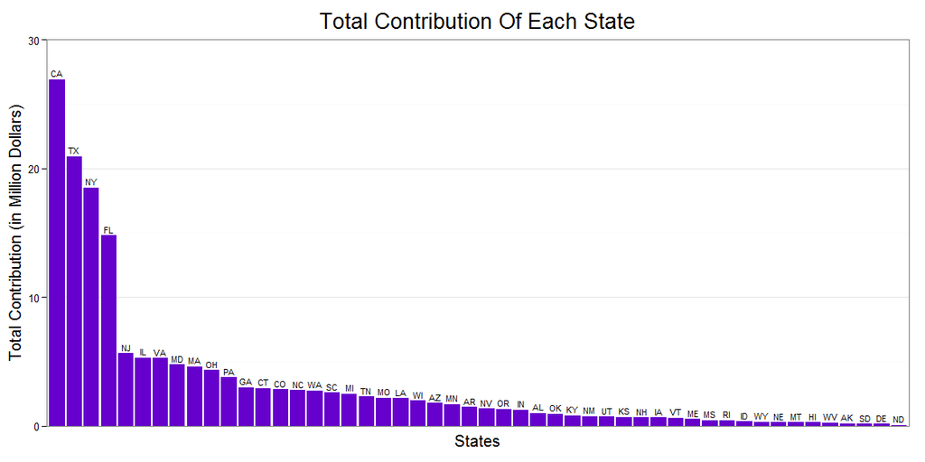

#### Description

California, Texas, New York, and Florida are way ahead of other states in term of total contribution in the election so far. However, these States are either very either very populated, or well-off, or both.

## Plot Two

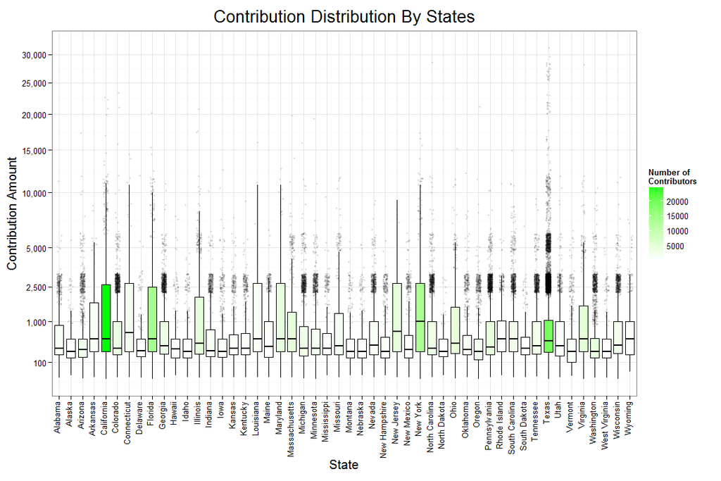

#### Description

Most states have the first and third quartiles between $100 and $1000. New York has the highest median (at $1000) and a relatively high number of contributors. Texas also stands out with lots of outliers: Many are well above $10,000.

## Plot Three

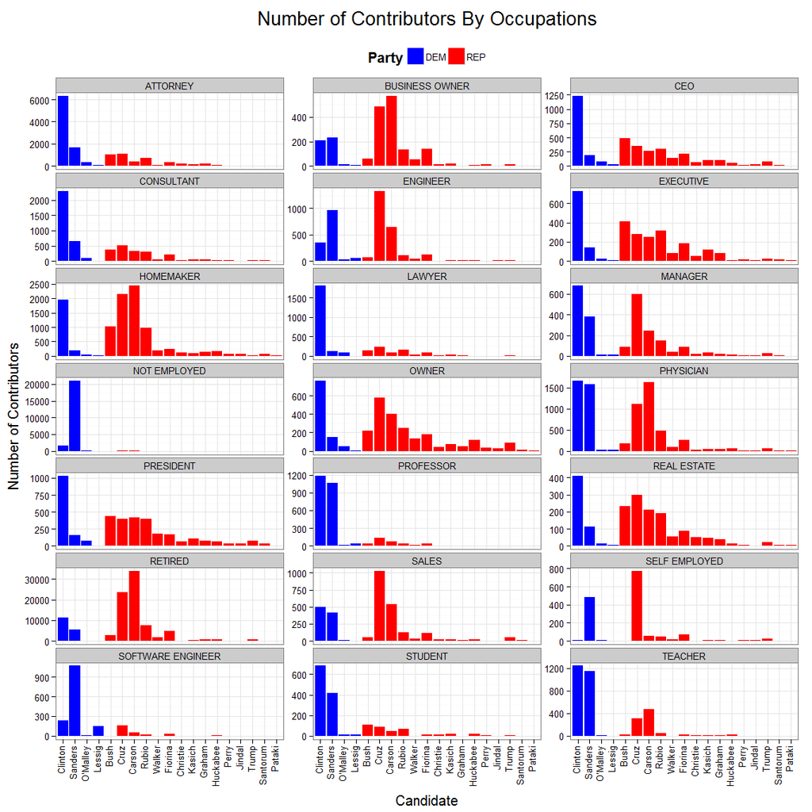

#### Description

Interestingly enough, Software Engineers also much prefer Sanders than other candidates. In Education (Students, Teachers, Professors), Clinton and Sanders, the Democrat’s front runners, are also very popular. Meanwhile, the retired are mostly siding with the Republican candidates.

# 3. Reflection

I combined 8 different datasets about US 2016 Primary Election Contribution and US Economy to analyze the financial aspect of this election season.

In the Bivariate section, the data was first dissected by States to compare their total contribution, number of contributors with various other economic features. I was surprised to find that Vermont was the most involved State. I then tried to find a correlation between the Involvement index vs. GDP per capita, Median Household Income, and Disposable Personal Income per capita. Unfortunately, there were no correlations. There must be other social factors, which this data doesn’t capture, that can be better used to predict the Involvement of each State.

In the Multivariate section, I explored the contribution and expenditure of the candidates. There was proof and Trump standing by his word (mostly!) about not asking for donation money. I also found proof of Sanders’ popularity among the lower and middle classes. I wish the dataset provided by FEC includes more info about the contributors like Income, Gender, Age, Race, and Sexuality. Those features would have given us a fuller pictures of who are standing behind these candidates.

# 4. References

1. GGplot2 cheatsheet: http://zevross.com/blog/2014/08/04/beautiful-plotting-in-r-a-ggplot2-cheatsheet-3/
2. Pass Arguments to dplyr functions: http://stackoverflow.com/questions/27975124/pass-arguments-to-dplyr-functions
3. Using Lazyeval: https://cran.r-project.org/web/packages/lazyeval/vignettes/lazyeval.html
4. Plot outliers seperately: http://stackoverflow.com/questions/15273148/coloring-boxplot-outlier-points-in-ggplot2